# Week 4 Slides

## Gene Expression

## Gene Expression

- Gene expression: the process by which information from a gene is used in the synthesis of functional gene products that affect a phenotype.
- Gene expression studies are often focused on protein coding genes
- Many functional expressed molecules
  - protein coding genes
  - [lncRNAs](https://en.wikipedia.org/wiki/Long_non-coding_RNA)
  - [transfer RNAs](https://www.genome.gov/genetics-glossary/Transfer-RNA)
  - microRNAs

## Gene Expression Process

- Specific parts of the genome code for genes
- Gene sequences *transcribed* into RNA molecules called *transcripts*
- In lower organisms (e.g. bacteria), RNA molecules passed directly to ribosomes
- In most higher organisms (i.e. eukaryotes):
  1. Initial transcripts, called *pre-messenger RNA (pre-mRNA) transcripts* are processed via splicing
  2. Splicing removes certain parts of pre-mRNA (*introns*) and concatenates adjacent sequences (*exons*) together into *mature RNA (mRNA)*
  3. mRNA exported from nucleus to be translated at ribosomes

## Gene Expression Process

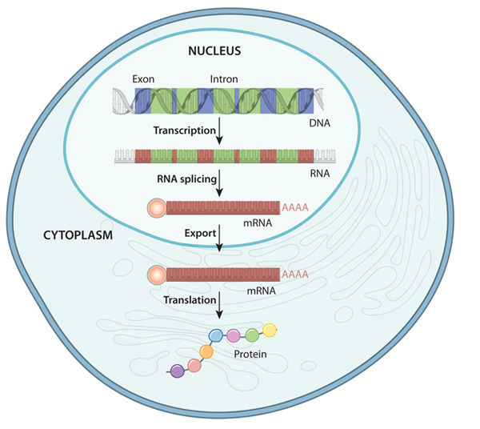

## Gene Expression Measurements

- Measurements proportional to abundance (or copy number) of RNA transcripts
- Measurements are always non-negative
- Usually *relative* to some normalizing quantity
  - i.e. a value of zero does *not* mean gene is not expressed!
- Some methods (e.g. digital droplet PCR) can estimate absolute abundance (i.e. exact number of copies)

## Gene Expression Assays

- Many ways to measure the abundance of RNA transcripts
  - Light absorbance
  - [Northern blot](https://www.genome.gov/genetics-glossary/Northern-Blot)
  - [quantitative polymerase chain reaction (qPCR)](https://www.thermofisher.com/blog/ask-a-scientist/what-is-qpcr/)
  - Oligonucleotide and microarrays
  - High throughput RNA sequencing (RNASeq)

## Gene Expression Data in Bioconductor

## Gene Expression Data in Bioconductor

- [SummarizedExperiment container](https://bioconductor.org/packages/release/bioc/html/SummarizedExperiment.html) standard way to load and work with gene expression data in Bioconductor
- Stores the following information:
  - `assays` - one or more measurement assays (e.g. gene expression) in the form of a feature by sample matrix
  - `colData` - metadata associated with the samples (i.e. columns) of the assays
  - `rowData` - metadata associated with the features (i.e. rows) of the assays
  - `exptData` - additional metadata about the experiment itself, like protocol, project name, etc

## SummarizedExperiment Schematic

[figure not shown]

## Creating SummarizedExperiments

- Many Bioconductor packages for specific types of data, e.g. limma create SummarizedExperiment objects for you
- You may also create your own…

## Creating `SummarizedExperiment`s

```r
# microarray expression dataset intensities
intensities <- readr::read_delim(
  "example_intensity_data.csv",delim=" "
)

# the first column of intensities tibble is the probesetId,
# extract to pass as rowData
rowData <- intensities["probeset_id"]

# remove probeset IDs from tibble and turn into a R dataframe
# so that we can assign rownames since tibbles don't support
# row names
intensities <- as.data.frame(
  select(intensities, -probeset_id)
)
rownames(intensities) <- rowData$probeset_id
```

## `SummarizedExperiment` cont’d

```r
# these column data are made up, but you would have a
# sample metadata file to use
colData <- tibble(
  sample_name=colnames(intensities),
  condition=sample(c("case","control"),ncol(intensities),replace=TRUE)
)

se <- SummarizedExperiment(
   assays=list(intensities=intensities),
   colData=colData,
   rowData=rowData
)
```

## `SummarizedExperiment` cont’d

```r
se
## class: SummarizedExperiment
## dim: 54675 35
## metadata(0):
## assays(1): intensities
## rownames(54675): 1007_s_at 1053_at ... AFFX-TrpnX-5_at AFFX-TrpnX-M_at
## rowData names(1): probeset_id
## colnames(35): GSM972389 GSM972390 ... GSM972512 GSM972521
## colData names(2): sample_name condition
```

## Microarrays

## Microarrays

[figure not shown]

- Microarrays: devices that measure relative abundance of DNA molecules
- Measure 1000s of DNA molecules simultaneously
- Molecules are selected *a priori* and “hard coded” onto the device

## Types of Microarrays

- Microarrays measure DNA
- Usually one microarray is generated for an individual sample
- Sample preparation method depends on target molecules
  - DNA: e.g. genetic variants, the DNA itself is biochemically extracted
  - RNA abundance: RNA extracted then reverse transcribed to complementary DNA (cDNA)

## Microarray Terminology

- **probe** - short (~25nt) cDNA molecule complementary to portion of target transcript
- **probe set** - a set of probes that all target the same gene
- **flowcell** - the glass slide portion of device that has probes deposited on it

## Microarray Design

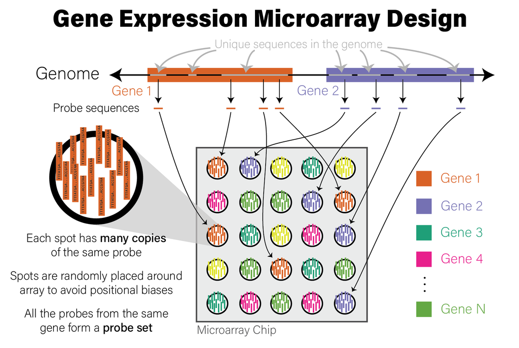

## Microarray Data Generation Process

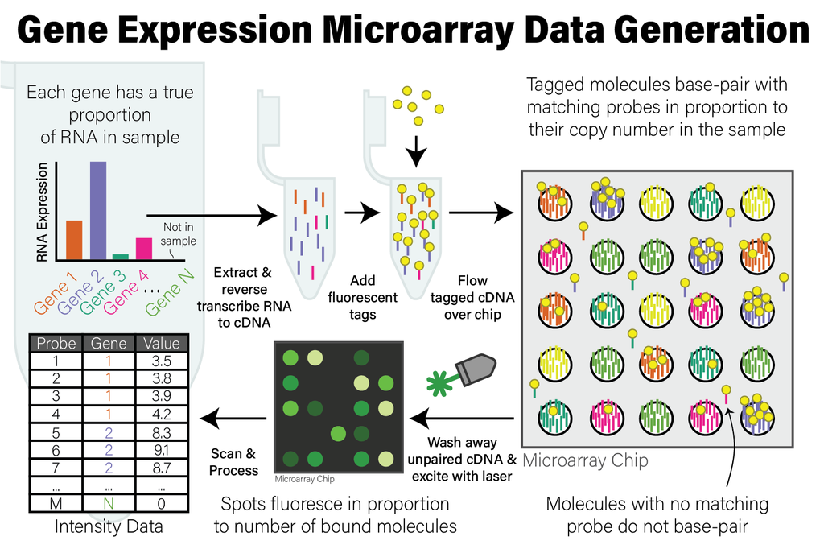

## Microarray Gene Expression Data

## Microarray Gene Expression Data

Four steps involved in analyzing gene expression microarray data:

1. **Summarization of probes to probesets**
2. **Normalization**
3. **Quality control**
4. **Analysis**

## Microarray Data

- Raw probe intensity data stored in CEL data files
- [`affy` Bioconductor package](https://www.bioconductor.org/packages/release/bioc/html/affy.html)
  - Loads CEL files into Bioconductor objects
  - Performs key preprocessing operations
- Typically have many CEL files, one per each sample

## Reading CEL Files

- Load CEL files with `affy::ReadAffy` function

```r
# read all CEL files in a single directory
affy_batch <- affy::ReadAffy(celfile.path="directory/of/CELfiles")

# or individual files in different directories
cel_filenames <- c(
  list.files( path="CELfile_dir1", full.names=TRUE, pattern=".CEL$" ),
  list.files( path="CELfile_dir2", full.names=TRUE, pattern=".CEL$" )
)
affy_batch <- affy::ReadAffy(filenames=cel_filenames)
```

## Probe summarization and normalization

- `affy` package provides functions to perform probe summarization and normalization
- Robust Multi-array Average (RMA) state of the art method for normalization
- `affy::rma` function implements RMA, performs summarization and normalization of multiple arrays simultaneously

## Aside: R package data

- Some packages include data with the R functionality
- Load package data into your workspace with `data()` function

```r
library(affydata)
data(Dilution)
```

## RMA normalization

```r
library(affy)
library(affydata)
data(Dilution)

# normalize the Dilution microarray expression values
# note Dilution is an AffyBatch object
eset_rma <- affy::rma(Dilution,verbose=FALSE)
```

## `ExpressionSet` vs `SummarizedExperiment`

- `ExpressionSet` is a container that contains high throughput assay data
- Similar to and superseded by `SummarizedExperiment`
- Some older packages (notably `affy`) return `ExpressionSet` objects, not `SummarizedExperiment`s
- Similar interface, but some key differences

| Operation | ExpressionSet | SummarizedExperiment |
| --- | --- | --- |
| Get expression values | `exprs(eset)` | `assays(se)` |
| Get column data | `phenoData(eset)` | `colData(se)` |
| Get row data | `annotation(eset)` | `rowData(se)` |

## RMA normalization

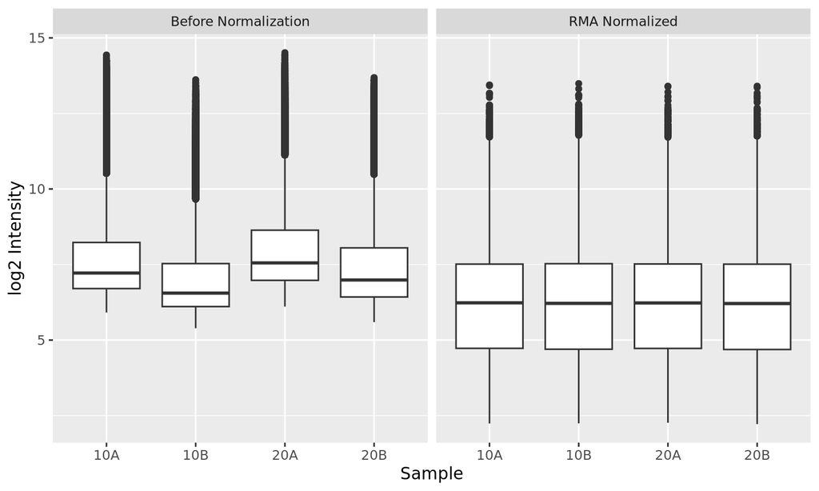

## Grammar of Graphics

## Grammar of Graphics

[figure not shown]

## `ggplot2`

- [ggplot2](https://ggplot2.tidyverse.org/) R package that implements grammar of graphics
- Written by Hadley Wickham in 2005

## `ggplot2` Fundamentals

- Every plot is the combination of three types of information:
  1. **data** (i.e. values)
  2. **geometry** (i.e. shapes)
  3. **aesthetics** (i.e. connects values and shapes)

## `ggplot2` Example

- A simple example dataset:

  ```r
  ## # A tibble: 20 × 8
  ##    ID    age_at_death condition    tau  abeta   iba1   gfap braak_stage
  ##    <chr>        <dbl> <fct>      <dbl>  <dbl>  <dbl>  <dbl> <fct>
  ##  1 A1              73 AD         96548 176324 157501  78139 4
  ##  2 A2              82 AD         95251      0 147637  79348 4
  ##                              ...
  ## 10 A10             69 AD         48357  27260  47024  78507 2
  ## 11 C1              80 Control    62684  93739 131595 124075 3
  ## 12 C2              77 Control    63598  69838   7189  35597 3
  ##                              ...
  ## 20 C10             73 Control    15781  16592  10271 100858 1
  ```

## Sidebar: Tau pathology

[figure not shown]

## `ggplot2` Example

- Goal: visualize the relationship between age at death and the amount of tau pathology
- Try a scatter plot where each marker is a subject with
  - \(x\) is `age_at_death`
  - \(y\) is `tau`

  ```r
  ggplot(
      data=ad_metadata,
      mapping = aes(
        x = age_at_death,
        y = tau
      )
    ) +
    geom_point()
  ```

## Simple Scatter Plot

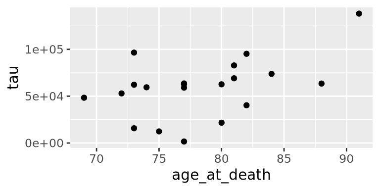

```r
ggplot(data=ad_metadata, mapping=aes(x=age_at_death, y=tau)) +
  geom_point()
```

## `ggplot2` Plot Components

```r
ggplot(data=ad_metadata, mapping=aes(x=age_at_death, y=tau)) +
  geom_point()
```

1. `ggplot()` - function creates a plot
2. `data=` - pass a tibble with the **data**
3. `mapping=aes(...)` - Define an **aesthetics** mapping connecting data to plot properties
4. `geom_point(...)` - Specify **geometry** as points where marks will be made at pairs of x,y coordinates

## Adding More Aesthetics

Is this the whole story?

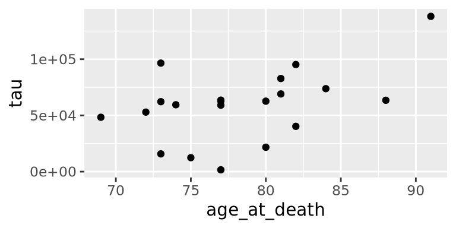

## Adding More Aesthetics

- There are both AD and Control subjects in this dataset!
- How does `condition` relate to this relationship we see?
- Layer on an additional aesthetic of color:

  ```r
  ggplot(
      data=ad_metadata,
      mapping = aes(
        x = age_at_death,
        y = tau,
        color=condition # color each point
      )
    ) +
    geom_point()
  ```

## Adding More Aesthetics

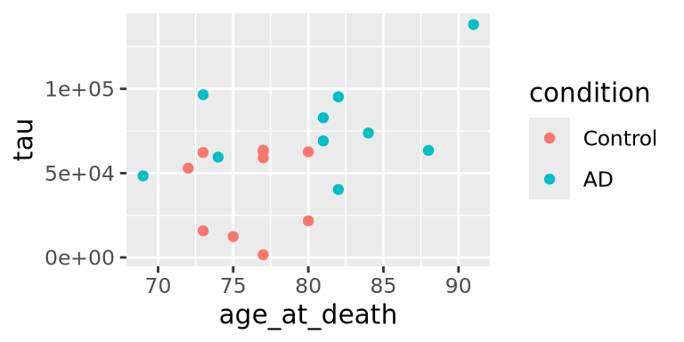

```r
ggplot(data=ad_metadata, mapping=aes(
      x=age_at_death, y=tau, color=condition
    )) + geom_point()
```

## Other Plot Geometries

- Differences in distributions of variables can be important
- Examine the distribution of `age_at_death` for AD and Control samples with [violin geometry](https://ggplot2.tidyverse.org/reference/geom_violin.html) with `geom_violin()`:

  ```r
  ggplot(data=ad_metadata, mapping = aes(x=condition, y=age_at_death)) +
    geom_violin()
  ```

## Violin Plot

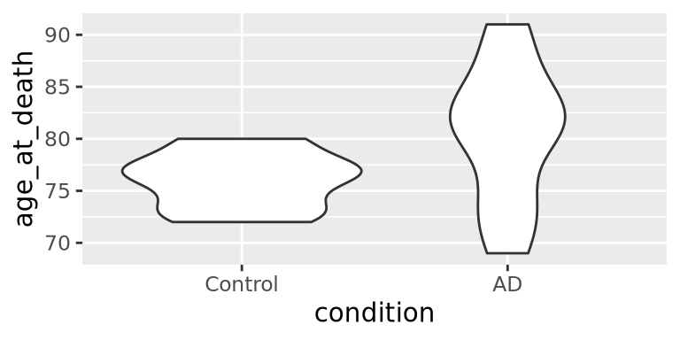

```r
ggplot(data=ad_metadata, mapping = aes(x=condition, y=age_at_death)) +
  geom_violin()
```

## Multiple Plots

- Can put multiple plots in one figure with `patchwork` library:

```r
library(patchwork)
age_boxplot <- ggplot(
    data=ad_metadata,
    mapping = aes(x=condition, y=age_at_death)
  ) +
  geom_boxplot()
tau_boxplot <- ggplot(
    data=ad_metadata,
    mapping=aes(x=condition, y=tau)
  ) +
  geom_boxplot()

age_boxplot | tau_boxplot # this puts the plots side by side
```

## Side by Side Plots

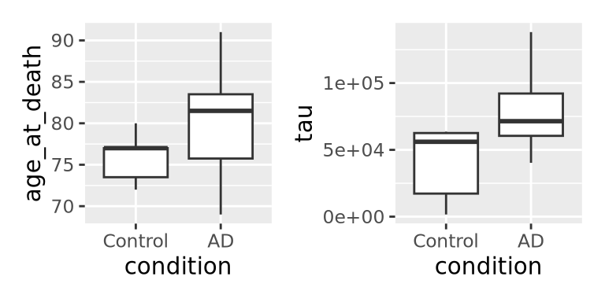

```r
age_boxplot | tau_boxplot # this puts the plots side by side
```

## R Graph Gallery

- Useful collection of plot types and examples:
- [R Graph Gallery](https://www.r-graph-gallery.com/)

## `ggplot` Mechanics

## `ggplot` Mechanics

- `ggplot` has two key concepts that give it great flexibility: **layers** and **scales**
- A *layer* is one set of data drawn with a geometry and an aesthetic
- A *scale* is the mapping from the data values to visual properties
- A plot may have one or more layers
- Different layers may share scales or have their own

## `ggplot` Layers

- Each layer is a set of data connected to a geometry and an aesthetic
- Each `geom_X()` function adds a layer to a plot
- The plot has three layers:

  ```r
  ggplot(data=ad_metadata, mapping=aes(x=age_at_death)) +
    geom_point(mapping=aes(y=tau, color='blue')) +
    geom_point(mapping=aes(y=abeta, color='red')) +
    geom_point(mapping=aes(y=iba1, color='cyan'))
  ```

## `ggplot` Layers

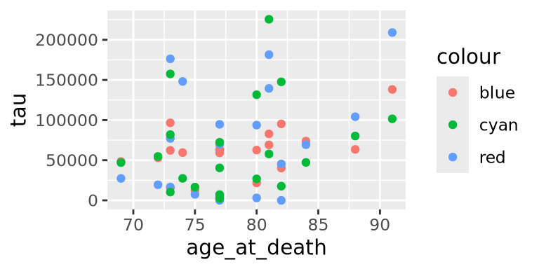

## `ggplot` Scales

- A scale maps data onto a range, e.g.:
  - pixel range
  - color on a gradient/set of colors
  - shape type, circle or square
  - shape dimension, like circle radius
- Multiple layers on the same plot
  - Must share at least one scale to be plotted together
  - May differ in one or more scales to be distinguished from each other

## `ggplot` Scales

How many layers? How many scales?

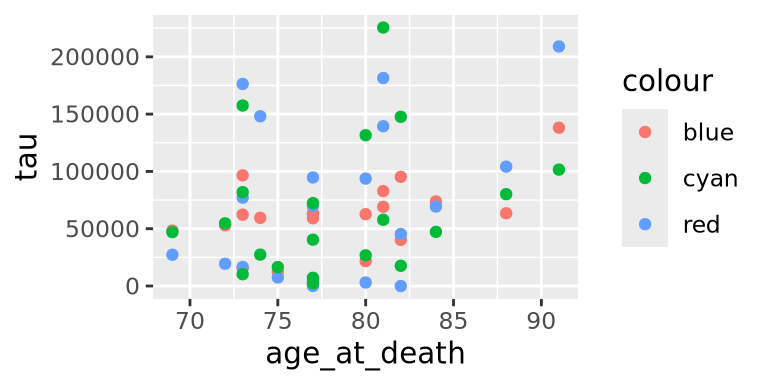

## `ggplot` Incompatible Scales

```r
ggplot(data=ad_metadata, mapping=aes(x=braak_stage)) +
  geom_point(mapping=aes(y=tau, color='blue')) +
  geom_point(mapping=aes(y=age_at_death, color='red'))
```

## `ggplot` Incompatible Scales

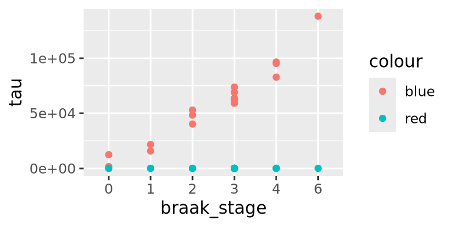

## Plotting One Dimension

## Bar Charts

## Bar chart

- Map length (i.e. height or width of rectangle) proportional to scalar value

```r
ggplot(ad_metadata,
  mapping = aes(
    x=ID,
    y=tau)
  ) +
  geom_bar(stat="identity")
```

## Bar chart

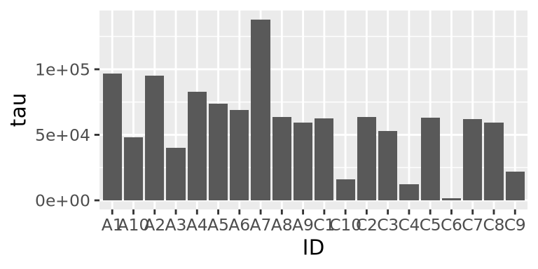

```r
ggplot(ad_metadata, mapping = aes(x=ID,y=tau)) +
  geom_bar(stat="identity")
```

## More insightful bar chart

- Change the fill color of the bars based on condition:

```r
ggplot(ad_metadata,
  mapping = aes(
    x=ID,
    y=tau,
    fill=condition)
  ) +
  geom_bar(stat="identity")
```

## More insightful bar chart

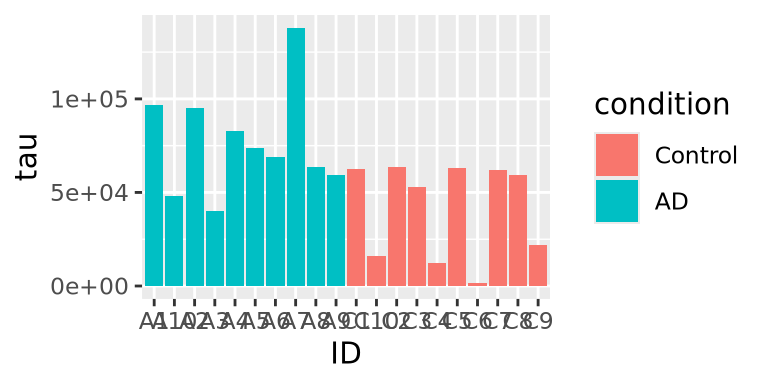

```r
ggplot(ad_metadata, mapping = aes(x=ID,y=tau,fill=condition)) +
  geom_bar(stat="identity")
```

## Diverging bar chart

- Bar charts can also plot negative numbers

```r
mutate(ad_metadata, tau_centered=(tau - mean(tau))) %>%
  ggplot(mapping = aes(
    x=ID,
    y=tau_centered,
    fill=condition)
  ) +
  geom_bar(stat="identity")
```

## Diverging bar chart

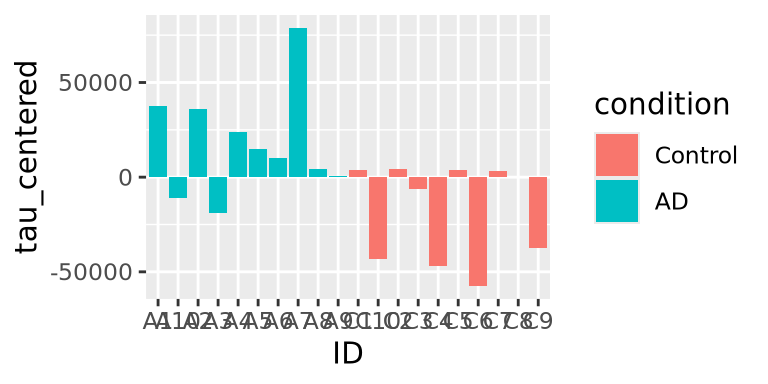

```r
mutate(ad_metadata, tau_centered=(tau - mean(tau))) %>%
  ggplot(mapping = aes(x=ID, y=tau_centered, fill=condition)) +
  geom_bar(stat="identity")
```

## Lollipop plots

## Lollipop plots

- Similar to bar charts, “lollipop plots” replace bar with a line segment and a circle
- No dedicated geometry - use `geom_point` and `geom_segment` layers:

```r
ggplot(ad_metadata) +
  geom_point(mapping=aes(x=ID, y=tau)) +
  geom_segment(mapping=aes(x=ID, xend=ID, y=0, yend=tau))
```

## Lollipop plots

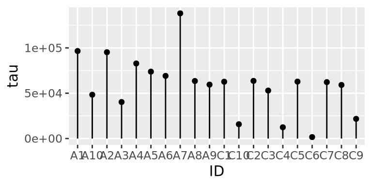

```r
ggplot(ad_metadata) +
  geom_point(mapping=aes(x=ID, y=tau)) +
  geom_segment(mapping=aes(x=ID, xend=ID, y=0, yend=tau))
```

## Stacked Area charts

## Stacked Area charts

- Visualize multiple 1D data that share a common categorical axis

```r
pivot_longer(
    ad_metadata,
    c(tau,abeta,iba1,gfap),
    names_to='Marker',
    values_to='Intensity'
  ) %>%
  ggplot(aes(x=ID,y=Intensity,group=Marker,fill=Marker)) +
    geom_area()
```

## Stacked Area charts

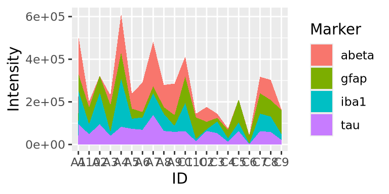

## Stacked Area Charts Components

Stacked area plots require three pieces of data:

- **x** - a numeric or categorical axis for vertical alignment
- **y** - a numeric axis to draw vertical proportions
- **group** - a categorical variable that indicates which (x,y) pairs correspond to the same line

## Proportional Stacked Area Charts

- Can view the relative proportion of values in each category rather than the actual values

```r
pivot_longer(
    ad_metadata,
    c(tau,abeta,iba1,gfap),
    names_to='Marker',
    values_to='Intensity'
  ) %>%
  group_by(ID) %>% # divide each intensity values by sum markers
  mutate(
    `Relative Intensity`=Intensity/sum(Intensity)
  ) %>%
  ungroup() %>% # ungroup restores the tibble to original number of rows
  ggplot(aes(x=ID,y=`Relative Intensity`,group=Marker,fill=Marker)) +
    geom_area()
```

## Proportional Stacked Area Charts

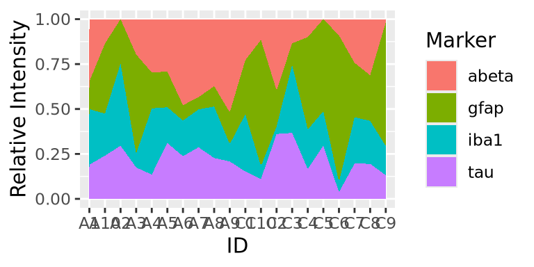

## Visualizing Distributions

## Visualizing Distributions

- A distribution describes the general “shape” of a set of numbers
  - i.e. what is the relative frequency of the values, or ranges of values
- Must understand distribution of data to choose statistical methods appropriately

## Histogram

## Histogram

- First described by Karl Pearson
- Type of bar chart
- Divides up the range of a dataset from minimum to maximum into bins usually of the same size
- Each bin represented by a bar with height or width proportional to number of values that fall within that bin

```r
ggplot(ad_metadata) +
  geom_histogram(mapping=aes(x=age_at_death))
```

## Histogram

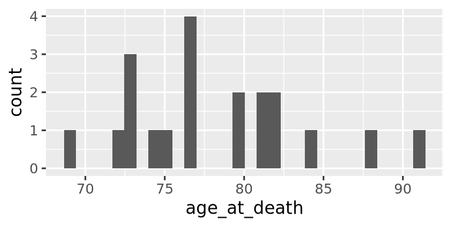

## Changing histogram bins

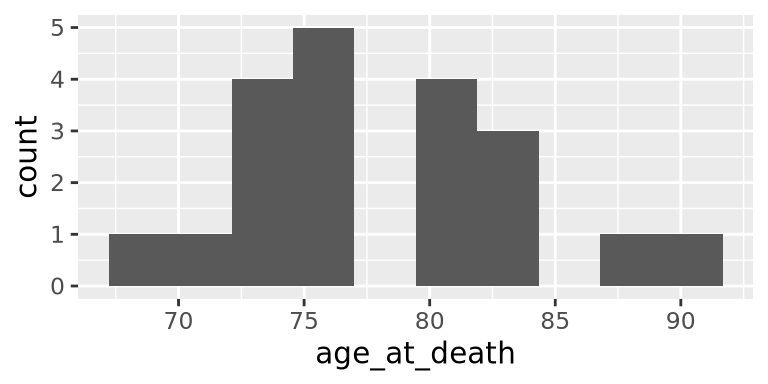

```r
ggplot(ad_metadata) +
  geom_histogram(mapping=aes(x=age_at_death),bins=10)
```

## Histograms sensitive to number of data points

- Histogram of synthetic dataset of 1000 normally distributed values:

```r
tibble(x=rnorm(1000)) %>%
  ggplot() +
  geom_histogram(aes(x=x))
```

## Histograms sensitive to number of data points

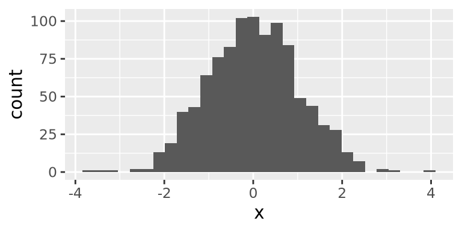

## Histograms with multiple distributions

- Can add multiple histograms to same plot

```r
tibble(
  x=c(rnorm(1000),rnorm(1000,mean=4)),
  type=c(rep('A',1000),rep('B',1000))
) %>%
  ggplot(aes(x=x,fill=type)) +
  geom_histogram(bins=30, alpha=0.6, position="identity")
```

## Histograms with multiple distributions

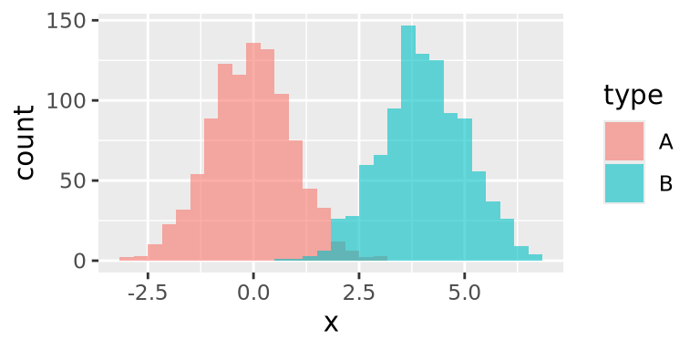

## Density plots

## Density plot

- Similar to histogram, except instead of binning the values draws a smoothly interpolated line that approximates the distribution
- Density plot is always normalized so the integral under the curve is approximately 1

  ```r
  ggplot(ad_metadata) +
    geom_density(mapping=aes(x=age_at_death),fill="#c9a13daa")
  ```

## Density plot

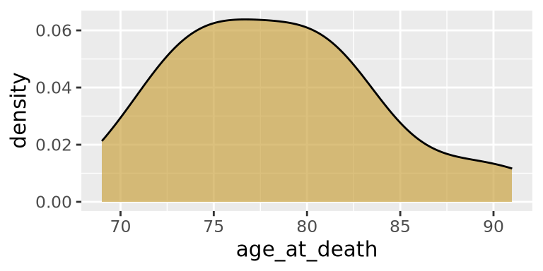

## Density plot vs histogram

```r
library(patchwork)
hist_g <- ggplot(ad_metadata) +
  geom_histogram(mapping=aes(x=age_at_death),bins=30)
density_g <- ggplot(ad_metadata) +
  geom_density(mapping=aes(x=age_at_death),fill="#c9a13daa")

hist_g | density_g
```

## Density plot vs histogram

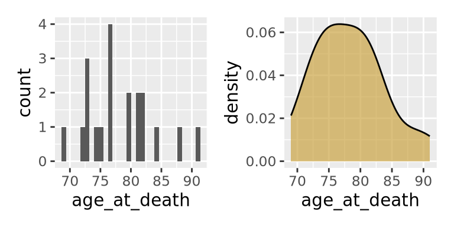

## Density plot vs histogram

```r
library(patchwork)
normal_samples <- tibble(
  x=c(rnorm(1000),rnorm(1000,mean=4)),
  type=c(rep('A',1000),rep('B',1000))
)
hist_g <- ggplot(normal_samples) +
  geom_histogram(
    mapping=aes(x=x,fill=type),
    alpha=0.6, position="identity", bins=30
)
density_g <- ggplot(normal_samples) +
  geom_density(
    mapping=aes(x=x,fill=type),
    alpha=0.6, position="identity"
  )

hist_g | density_g
```

## Density plot vs histogram

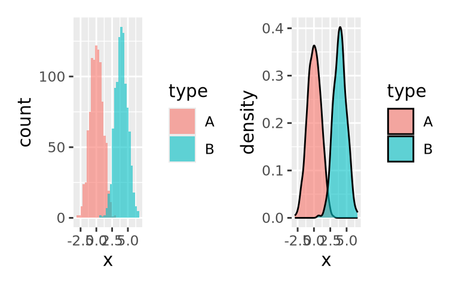

## Boxplots

## Boxplot

```r
ggplot(ad_metadata) +
  geom_boxplot(mapping=aes(x=condition,y=age_at_death))
```

## Boxplot

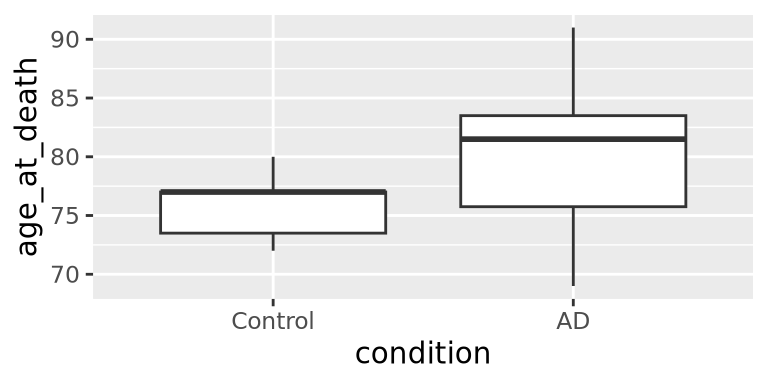

```r
ggplot(ad_metadata) +
  geom_boxplot(mapping=aes(x=condition,y=age_at_death))
```

## Boxplot Anatomy

[figure not shown]